# Decision support based on AI in medical imaging

AI in medical imaging (AIBIA) parallel session

[Wouter van Amsterdam, MD, PhD](https://vanamsterdam.github.io)

Department of Data Science Methods, Julius Center, University Medical Center Utrecht

2024-05-15

## Outline

1. different uses of AI in medical imaging
2. using AI for treatment effect estimation
3. warning: harmful self-fulfilling prophecies

# Uses of AI in medical imaging

## Uses of AI in medical imaging

1. Acquisition ($S \to X$)
2. detection / segmentation ($X \to X$)
3. inference / diagnosis ($X \to D$, both at prediction time)
4. prognosis ($X \to Y$, $Y$ in the future)
5. treatment effect ($X$ determines effect of a treatment)

## Why would you estimate treatment effects based on images?

- treatments have different effects on patients based on their (disease) characteristics
- for example, whether tamoxifen increases survival for breast cancer patients depends on whether their tumor is hormone sensitive
- some characteristics may be well captured in medical imaging:
  - T-cell distributions around tumors related to effect of immunotherapy in cancer

## How to estimate treatment effects based on images?

In principle the same as estimating a subgroup treatment effect (e.g. male vs female)

1. Conduct a randomized controlled trial where the treatments of interest are randomly allocated
2. Collect (imaging) data at randomization timepoint
3. Use a statistical learning technique like TARnet (Shalit et al. 2017) to estimate outcomes conditional on image and treatment
4. conditional treatment effect $= f(X,T=1) - f(X,T=0)$

**What if you cannot do a (big enough) RCT?**

Emulate / approximate the ideal trial in observational data you do have, using **causal inference** techniques

**(which rely on untestable assumptions)**

## The in-between: predicting prognosis and using the predictions for decision support

For example:

1. give chemotherapy to cancer patients with high predicted risk of recurrence
2. give statins to patients with a high risk of a heart attack

**TRIPOD+AI on prediction models (Collins et al. 2024)**

“Their primary use is to support clinical decision making, such as … **initiate treatment or lifestyle changes.**”

**This may lead to bad situations when:**

1. ignoring the treatments patients may have had during training / validation
2. only considering measures of predictive accuracy as sufficient evidence for safe deployment
3. predictive accuracy (AUC) may be measured pre- or post-deployment of the model

# When accurate prediction models yield harmful self-fulfilling prophecies

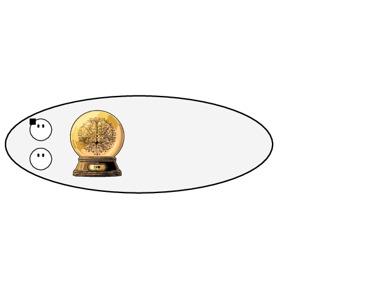

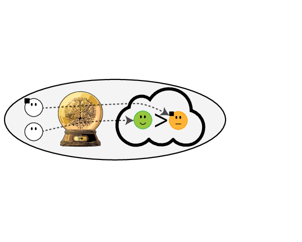

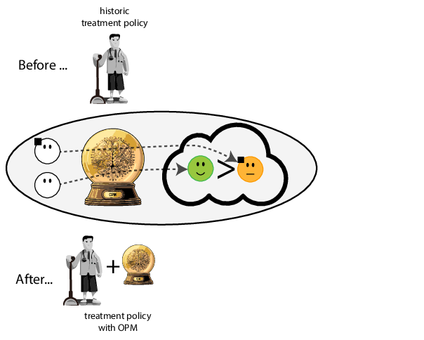

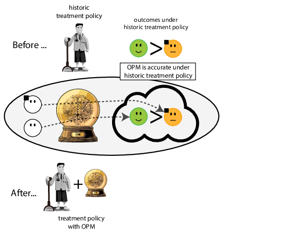

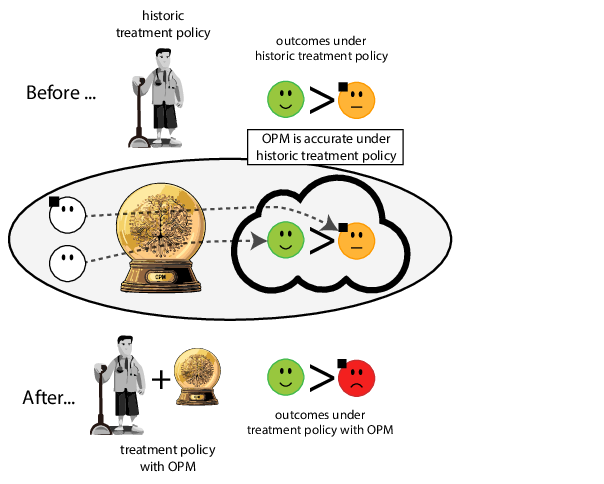

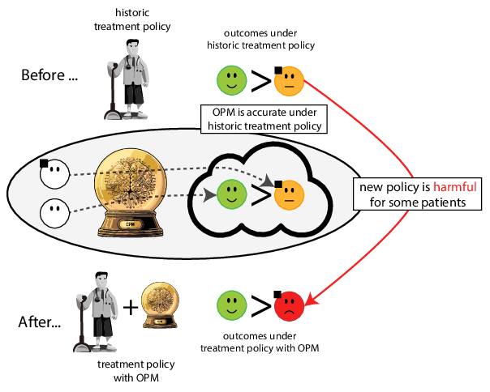

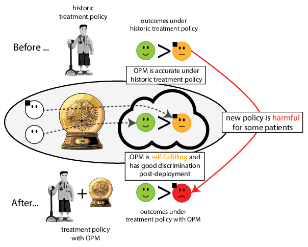

## When building a prediction model, always discuss

1. what treatments are assumed in the predicted risk?
2. what is the effect of using the model on the treatment policy?
3. what is the effect on patient outcomes?

[figure not shown]

From algorithms to action: improving patient care requires causality (W. A. C. van Amsterdam et al. 2024b)

[figure not shown]

When accurate prediction models yield harmful sel-fulfilling prophecies (W. A. C. van Amsterdam et al. 2024a)

## References

Amsterdam, Wouter A. C. van, Nan van Geloven, Jesse H. Krijthe, Rajesh Ranganath, and Giovanni Ciná. 2024a. *When Accurate Prediction Models Yield Harmful Self-Fulfilling Prophecies*. arXiv. https://doi.org/10.48550/arXiv.2312.01210.

Amsterdam, Wouter A. C. van, Pim A. de Jong, Joost J. C. Verhoeff, Tim Leiner, and Rajesh Ranganath. 2024b. “From Algorithms to Action: Improving Patient Care Requires Causality.” *BMC Medical Informatics and Decision Making* 24 (1). https://doi.org/10.1186/s12911-024-02513-3.

Collins, Gary S., Karel G. M. Moons, Paula Dhiman, et al. 2024. “TRIPOD+AI Statement: Updated Guidance for Reporting Clinical Prediction Models That Use Regression or Machine Learning Methods.” *BMJ* 385 (April): e078378. https://doi.org/10.1136/bmj-2023-078378.

Shalit, Uri, Fredrik D. Johansson, and David Sontag. 2017. “Estimating Individual Treatment Effect: Generalization Bounds and Algorithms.” *arXiv:1606.03976 [Cs, Stat]*, May. http://arxiv.org/abs/1606.03976.